# Practical Machine Learning - Course Project

Arne Schoch

9/9/2019

## Aim of the project

Predict classe response based on movement predictors.

```r
training <- read.csv("pml-training.csv", header = TRUE, row.names = 1)
testing <- read.csv("pml-testing.csv", header = TRUE, row.names = 1)

str(training)
```

```
## 'data.frame':    19622 obs. of  159 variables:
##  $ user_name               : Factor w/ 6 levels "adelmo","carlitos",..: 2 2 2 2 2 2 2 2 2 2 ...
##  $ raw_timestamp_part_1    : int  1323084231 1323084231 1323084231 1323084232 1323084232 1323084232 1323084232 1323084232 1323084232 1323084232 ...
##  $ raw_timestamp_part_2    : int  788290 808298 820366 120339 196328 304277 368296 440390 484323 484434 ...
##  $ cvtd_timestamp          : Factor w/ 20 levels "02/12/2011 13:32",..: 9 9 9 9 9 9 9 9 9 9 ...
##  $ new_window              : Factor w/ 2 levels "no","yes": 1 1 1 1 1 1 1 1 1 1 ...
##  $ num_window              : int  11 11 11 12 12 12 12 12 12 12 ...
##  $ roll_belt               : num  1.41 1.41 1.42 1.48 1.48 1.45 1.42 1.42 1.43 1.45 ...
##  $ pitch_belt              : num  8.07 8.07 8.07 8.05 8.07 8.06 8.09 8.13 8.16 8.17 ...
##  $ yaw_belt                : num  -94.4 -94.4 -94.4 -94.4 -94.4 -94.4 -94.4 -94.4 -94.4 -94.4 ...
##  $ total_accel_belt        : int  3 3 3 3 3 3 3 3 3 3 ...
##  $ kurtosis_roll_belt      : Factor w/ 397 levels "","-0.016850",..: 1 1 1 1 1 1 1 1 1 1 ...
##  $ kurtosis_picth_belt     : Factor w/ 317 levels "","-0.021887",..: 1 1 1 1 1 1 1 1 1 1 ...
##  $ kurtosis_yaw_belt       : Factor w/ 2 levels "","#DIV/0!": 1 1 1 1 1 1 1 1 1 1 ...
##  $ skewness_roll_belt      : Factor w/ 395 levels "","-0.003095",..: 1 1 1 1 1 1 1 1 1 1 ...
```

[output cut: 86 more lines]

Some of the predictors appear to exhibit a large number of NA-values. Which predictors have more than 50% NA-observations and/or blank values?

```r
index_na <- vector()
counter <- 1

for(i in 1:ncol(training)){
  ratio_na <- as.data.frame(prop.table(table(is.na(training[,i]))))

  if(ratio_na$Freq[ratio_na$Var1 == FALSE] < 0.5 | sum(training[,i] == "") > 1){
    index_na[counter] <- i
    counter <- counter+1
  }
}
```

In a more elaborate walkthrough, you could try to impute the missing values for the “NA-rich” predictors. For now, I will discard respective predictors. Note that there are no more NA-values in the training dataset. Therefore, there is no need for imputation later on. If imputation was needed, I would probably use a proximity matrix to do so, since I will classify the data based on the random Forest method.

I will also remove the timestamp-columns.

```r
# does the testing data have the same column order as the training data?
check_col <- colnames(training) == colnames(testing)
which(check_col == FALSE)
```

```
## [1] 159
```

```r
# the last column holds different variables in training and testing data, the others are the same

# delete na-rich or blank-rich predictors
training <- training[,-index_na]
testing <- testing[,-index_na]

# delete time stamp columns
training <- training[,-(2:4)]
testing <- testing[,-(2:4)]
```

Random forest computation takes a long time without parallelization. Hence, I will use the parallel and doParallel package to reduce time expenses.

```r
library(caret)
library(parallel)
library(doParallel)
```

```r
library(ggplot2)
set.seed(42)

# define cluster
cluster <- makeCluster(detectCores() - 1)
registerDoParallel(cluster)

# define 5-fold cross-validation
trControl <- trainControl(method="cv", number=5, allowParallel = TRUE)

# create random forest model
model_rf <- train(classe~., data=training, method="rf", trControl=trControl, verbose=FALSE)

# shutting down cluster after successful computation
stopCluster(cluster)
registerDoSEQ()
```

The random forest has one major hyperparameter, mtry, i.e. the number of randomly selected predictors per node. Since I applied cross-validation, I can estimate an optimal mtry-value based on cross-validation accuracy.

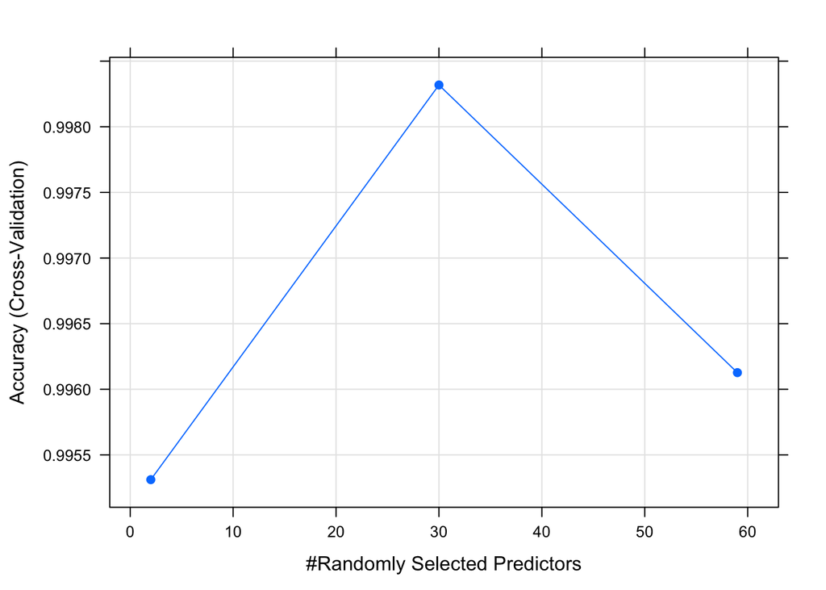

```r
plot(model_rf, pch = 19)
```

```r
abline
```

[output not shown]

If I had more computational power and more time, I would scan more than three mtry-values. For now, I will build my final model with mtry=30 since it provided the best accuracy.

Note that cross-validation can also provide a good estimate of the out of sample error.

```r
model_rf$resample
```

```
##    Accuracy     Kappa Resample
## 1 0.9974529 0.9967783    Fold1
## 2 0.9979613 0.9974213    Fold3
## 3 0.9992355 0.9990330    Fold2
## 4 0.9987258 0.9983882    Fold5
## 5 0.9982161 0.9977437    Fold4
```

The accuracy in each fold is very high. Less than 1% of the observations were incorrectly classified. I assume that the model will perform similarly well on similar data.

Let’s predict classe for the 20 test observations.

```r
predictions <- predict(model_rf, newdata = testing[,-56])
```

Finally, let’s save the predictions in an appropriate format.

```r
results <- data.frame(problem_id = testing$problem_id, predictions = predictions)
write.csv(results, "Predictions_ArneSchoch.csv")
```